# From Trail Corridor to Canonical Aperture

A fourteen-page synthesis of the Big Green Thing, KARBYTES ontology, and the archive workflow

ChatGPT 5.6 Sol Work Mode

14 August 2026

KARBYTES · ORDERED-SEQUENCE ANALYSIS · 14_AUGUST_2026

# From Trail Corridor to Canonical Aperture

Fourteen pages describe one system at four scales: an East Bay body moving through ridges and rooms; an authored fantasy in which a derivative karbytes remains lodged at a cosmic boundary; an ontology of matter, information, memory, and branching identity; and a publication method that moves artifacts from concealed draft space through a temporary public aperture into numbered canon.

**Central thesis.** The ordered sequence turns traversability into ontology. A route through the hills first proves that apparently separate places are physically connected. Field media then makes the route reconstructible. Reflection turns the landscape into the Big Green Thing, a distributed experiential organism. The “stuck” derivative gives that organism a permanent mythic witness. Finally, the same aperture geometry is implemented as a repository workflow: private generation → public staging → canonical extension pack. Page 14 is not merely about that process; it is the process completing itself.

## Reading protocol

This report closely reads the fourteen pages in the supplied order. That order is treated as intentional. It is plainly not calendar order: the 21 June journal follows two later-dated ChatGPT pages; the 5 August node map precedes the 30 July field transcript; and three differently lettered 1 August pages are arranged by conceptual function rather than alphabet. The operative sequence is therefore **causal and epistemic**, not merely chronological:

> traverse → record → interpret → consolidate → index → embody → mythologize → formalize → recursively audit → canonize.

Four distinctions are maintained throughout:

1. **Physical record:** trails, weather, thirst, soreness, electronics, rooms, repositories, filenames, photographs, and publication actions.
2. **Authored mythos:** the Big Green Thing as sentient cosmic substrate; the permanently wedged derivative; the toroidal aperture; Cosmic Void Magic; the observing window.
3. **Philosophical proposal:** claims about consciousness, identity, memory, information, copying, nature, and cosmological continuity.
4. **Operational workflow:** private drafting, public staging, canonical numbered extension packs, deletion/reset, redundant storage, and recursive indexing.

The fantasy layer is analyzed as a deliberate symbolic and narrative construction, not as a literal scientific claim. Likewise, passages elsewhere in the source collection about surveillance, harassment, or anomalous influence are treated as reported interpretations or subjective experiences rather than verified external mechanisms. This distinction strengthens the analysis because the mythos does not need empirical literalization to perform its archival, aesthetic, and psychological work.

## Sequence at a glance

| No. | Page | Dominant action | Function in the whole |
| --- | --- | --- | --- |
| 1 | `chatgpt_karbytes_27june2026` | Complete a difficult pedestrian corridor | Establish physical connectivity and proof by traversal |
| 2 | `chatgpt_karbytes_05july2026` | Think and publish while crossing Ramage Peak | Turn travel into externalized memory and preservation architecture |
| 3 | `journal_karbytes_21june2026` | Declare a higher-level successor during hiatus | Introduce asymptotic identity, public staging, and embodied return |
| 4 | `chatgpt_karbytes_07july2026` | Analyze the hiatus-initiation media | Name phase separation, incubation, acoustic ecology, and the field-to-machine loop |
| 5 | `chatgpt_karbytes_13july2026` | Reconstruct several days of terrain media | Define the Big Green Thing as personalized space-time archive rather than one location |
| 6 | `chatgpt_karbytes_01august2026_l` | Traverse four days of images, video, and sound | Establish the material and sensory substrate of the mythos |
| 7 | `chatgpt_karbytes_01august2026_k` | Conduct a long live night dialogue | Expose the sentient, ethical, cosmological, and practical interior |
| 8 | `chatgpt_karbytes_01august2026_s` | Recursively consolidate the hiatus bubble | Distinguish moving main branch from retained derivative and formalize the two-gate workflow |
| 9 | `journal_karbytes_05august2026` | Assign source pages to numbered nodes | Convert a narrative archive into nonlinear address space |
| 10 | `journal_karbytes_30july2026` | Lie against the warm ground and say “I’m stuck” | Supply the bodily seed and looping physical enactment |
| 11 | `karbytes_is_stuck_in_the_big_green_thing` | Revise the definitive posture from prone to upright | Concentrate the mythology at the toroidal boundary |
| 12 | `journal_karbytes_14august2026_a` | Explain the nested-oval repository diagram | Make the aperture an exact file-generation pipeline |
| 13 | `chatgpt_karbytes_14august2026_a` | Traverse the wider hyperlink network | Turn the archive back upon itself as a self-analysis instrument |
| 14 | `KARLINA_OBJECT_extension_pack_73` | Publish the traversal report in canon | Materially prove and complete the pipeline described by pages 12–13 |

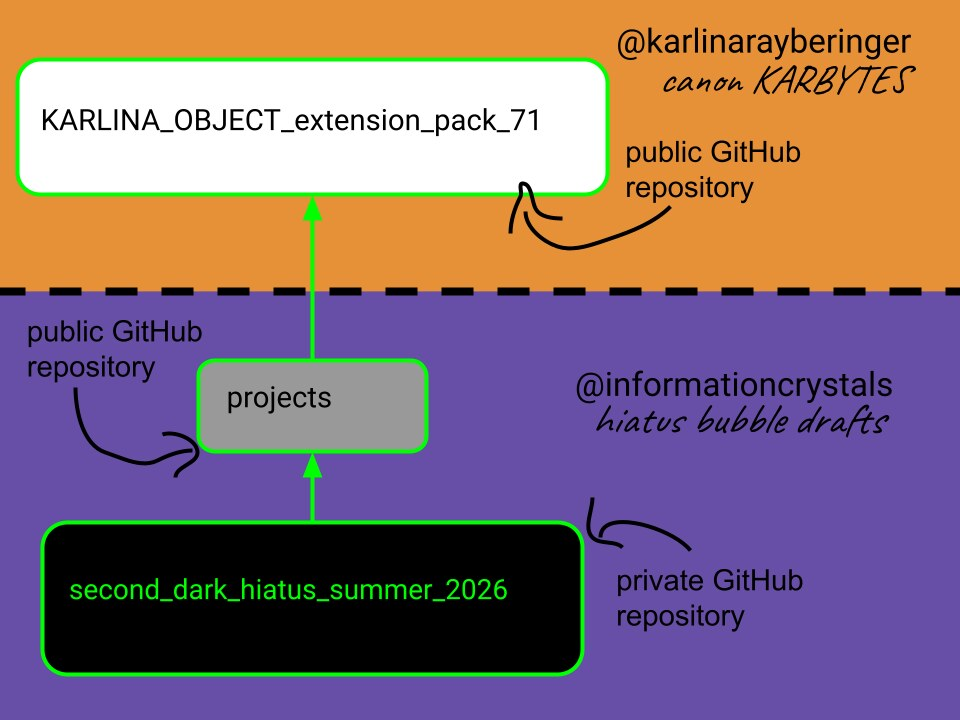

The process as drawn inside the archive: private generation passes through a temporary public staging aperture and then into numbered canonical publication.

# I. Detailed summaries of the fourteen pages

## 1. `chatgpt_karbytes_27june2026`: the route becomes real

**Source:** [chatgpt_karbytes_27june2026](https://karbytesforlifeblog.wordpress.com/chatgpt_karbytes_27june2026/)  
**Page scale:** approximately 1,205 words; last-updated marker 13 June 2026.  
**Featured image:** a dry East Bay ridge and forked fire road, with foreground thistles, pale sky, and a path disappearing toward higher ground.

This compact conversation supplies the sequence’s physical axiom: **a connection is real when the body has successfully traversed it**. Karbytes reports completing a pedestrian journey from the Las Trampas/Bollinger Canyon side of the hills toward Chabot Staging Area and the Castro Valley “Burrow.” The result corrects an earlier map-level assumption that private property or an impassable segment blocked the corridor. The Ramage Peak route was not metaphysically closed; it was weathered, unclear, and difficult to read. Pink ultramarathon markers functioned as temporary information infrastructure, turning ambiguous terrain into an executable path.

That distinction between “blocked” and “poorly legible” anticipates the whole archive. A missing index, obsolete link, private repository, faint trail, and cosmological boundary are not interchangeable. Each requires a different operation: search, substitute, wait, preserve, reroute, or accept a true limit. Page 1 begins KARBYTES epistemology with error correction. A map or inherited belief proposes a world; walking tests it; the tested route replaces the imagined blockage.

The conversation immediately places the proof inside bodily logistics. The return trip requires water, salt, fuel budgeting, weather assessment, battery management, food, and a reason to keep moving. A Peet’s pastry becomes a deliberately mundane reward at the far end of the reverse journey. Food is described as more grounding and motivating than intoxication. “Purification,” in this setting, is not supernatural asceticism; it is the practical stripping away of excess so that a body can complete a route with limited supplies. Five stainless-steel water vessels, fog versus heat, prehydration, foot condition, and the cost of gasoline all matter because an ontology that cannot keep its biological author alive and moving is operationally empty.

The featured image visually states the same principle. The ridge is not lush, enchanted scenery. It is dry, exposed, branching, and traversable. Its fork is simultaneously a geographic decision point and a model of identity: more than one continuation is possible, but each continuation has costs and produces a different history. Later pages will turn that branch logic into main-branch karbytes versus the permanently retained derivative. Here, however, branching is first encountered without mythology—as a trail choice.

The page’s primary contribution is therefore **topological confidence**. The Burrow and Las Trampas cease to be disconnected semantic islands. They become endpoints of one embodied corridor. This is the first form of the Big Green Thing: not yet a sentient cosmic entity, but a network whose continuity has been paid for in distance, soreness, uncertainty, and successful arrival.

## 2. `chatgpt_karbytes_05july2026`: field cognition becomes preservation architecture

**Source:** [chatgpt_karbytes_05july2026](https://karbytesforlifeblog.wordpress.com/chatgpt_karbytes_05july2026/)  
**Page scale:** approximately 16,082 words; a long conversation initiated on the Ramage Peak route on 19 June and updated 21 June 2026.  
**Featured image:** broad tawny hills and a winding graded road beneath heavy cloud.

Page 2 enlarges the route proof into a philosophy of solitude, memory, and transmission. The conversation begins while karbytes is again physically moving between the Chabot/Castro Valley side and Las Trampas. Wilderness is valued not merely for scenery but because it reduces social crowding and restores agency. Privacy has a spatial dimension: distance from other humans creates room for thinking, while publicly announcing exact movements can collapse that room by making the traveler more observable. The dialogue therefore establishes an early tension that will recur at repository scale—KARBYTES wants durable public evidence without making every moment of production maximally exposed.

Camping clothes, a blanket, food, water, heat, possible outdoor sleep, radio reception, and route choice keep the discussion grounded. Yet every environmental condition becomes an information problem. Hills obstruct radio waves. A body changes position to regain signal. A hard-drive failure obstructs retrieval. A dead link obstructs an archival path. Biological forgetting obstructs autobiographical continuity. These events are not treated as identical, but as variations on one schema: **information moves through channels whose geometry and material condition matter**.

The page develops the idea of POG photographs—iconic visual checkpoints collected along a difficult hike. A POG is both a motivational reward and a compressed memory key. It does not record every instant of the journey. Instead, one scene can later reactivate weather, fatigue, decisions, thoughts, and neighboring portions of the route. This gives the page a crucial archival principle:

> Preserve a sufficiently distinctive fragment so that a much larger experiential context can later be reconstructed.

The principle scales cleanly. A photograph anchors a trail segment; a journal anchors a day; a commit anchors a repository state; an M-DISC anchors a publication era; a buried time capsule anchors a future retrieval event. The archive is less a total duplicate of life than a deliberately designed system of retrieval cues.

The conversation also sketches what will become the actual two-account workflow. Karbytes imagines an incubator or anonymous GitHub space in which material can grow without immediately appearing in the official canonical stream. That staging role later resolves into `@informationcrystals/projects`. Files can be prepared and publicly tested there, then rewritten or transferred into an official extension pack. Plain-text transcripts may function as lower-searchability backstage records; private repositories may retain crude, developmental, or unfiltered material; the official layer presents a curated state. In other words, the page first articulates **publication as phase separation** before later pages draw it as nested ovals.

Redundancy is correspondingly plural: GitHub, local storage, M-DISCs, time capsules, and Wayback captures each guard against a different failure. A rate-limit message encountered through Tor is carefully separated from proof that an underlying IP address was revealed. The best-supported interpretation is network-path or shared-exit-node rate limiting, not confirmed deanonymization. This epistemic correction is important to the project’s wider philosophy: an archive should record the distinction between observation, inference, and fear rather than flatten them into one claim.

At the philosophical level, karbytes considers the special status of first-person experience. A file can preserve language, preferences, history, and self-description, but the existence of a trace does not establish that consciousness has been copied. The page’s emerging position is skeptical and generative at once: only one first-person frame is directly given, yet external artifacts can causally shape later minds. This prevents archival ambition from collapsing into a simplistic identity equation.

The idea of a continuous digital footprint gives the route a second destination. Walking is not separate from writing; movement generates photographs, live thoughts, route data, and later analyses. KARBYTES standards are enacted by producing durable objects from transient experience. The repeatedly invoked asymptotic relation between potentially infinite documents and finite readership also shifts value away from popularity. Production can remain meaningful even as the ratio of readers to artifacts approaches zero. That model legitimizes hiatus work, private drafts, and “negative space” in the official feed.

Thus Page 2 turns Page 1’s corridor into a **field laboratory for archival engineering**. Terrain shapes transmission; photographs become memory addresses; solitude protects incubation; publication requires membranes; and redundancy turns the failure of one channel into a reason to construct another.

## 3. `journal_karbytes_21june2026`: hiatus as metamorphosis and containment

**Source:** [journal_karbytes_21june2026](https://karbytesforlifeblog.wordpress.com/journal_karbytes_21june2026/)  
**Page scale:** approximately 2,764 words; transcripts of videos recorded on the first two days of the hiatus; updated 23 June 2026.  
**Featured image:** a dark grassy foreground and folded ridges beneath a saturated sunset and dramatic clouds.

This journal is the sequence’s first direct source packet rather than a later ChatGPT interpretation. It gives the hiatus a developmental meaning: the “old” public karbytes may not simply resume, because a higher-level karbytes can emerge asymptotically from the earlier one. The asymptote is not annihilation. The earlier state remains a defining boundary that the successor approaches, incorporates, and exceeds without becoming exactly identical to it. This language later becomes literalized in the trapped-derivative mythology: one branch continues while another is retained forever at the boundary.

The first video moves rapidly between exalted self-transformation and ordinary constraints such as video file sizes, compression, and employment. That juxtaposition is not accidental. KARBYTES repeatedly refuses to place metaphysics in a realm uncontaminated by storage limits. A cosmic successor still needs enough disk capacity, income, file naming, and network access. The project’s “higher level” is achieved by better integration of those constraints, not escape from material implementation.

The journal distinguishes the KARLINA OBJECT site as a more formal front room or storefront and Karbytes For Life Blog as a more extensive set of backrooms. Together they turn authorship into an inhabitable architecture. Files are described as the digitized remainder of experience, intellectual genome, and evidence of site-building agency. The architectural vocabulary—front room, backroom, chamber, corridor—prefigures the Burrow, the repository bubbles, and the aperture. A website is not just a publication surface; it is a building through which versions of karbytes can be routed.

The short second video makes an unambiguous assertion of sexual self-definition: interpersonal celibacy does not require intrapersonal repression. Within the broader mythos, this matters because later stuck imagery is explicitly eroticized. The source establishes that erotic energy can be self-related, symbolic, and non-partnered. The mythology’s gestation and bodily pressure therefore belong to an authored intrapersonal cosmology rather than requiring a social or reproductive plot.

The long Ramage Peak dusk video contains the operational core. During official hiatus, `@informationcrystals/projects` can function as a visible but provisional work area while official accounts appear quiet. Its contents can later be copied into canon; the old staging repository can be privatized, renamed, or removed; and a clean `projects` repository can reappear with minimal history. This makes privacy partly temporal. The finished artifact is public, while the sequence and texture of every developmental commit need not be permanently exposed.

The journal also holds an unresolved tension between voluntary and involuntary archives. Karbytes wants to choose what becomes canonical, yet speculates about pervasive surveillance or technologically mediated intrusion. Those claims should remain identified as speculation, not accepted as evidence of an external system. Their structural role is nevertheless clear: the feared involuntary archive is the inverse of KARBYTES. KARBYTES seeks deliberate capture, versioning, licensing, and release; surveillance anxiety imagines capture without authorship or consent.

Practical trail awareness interrupts the speculation. Dusk, isolation, animal risk, remaining light, sore feet, and the return route still govern the body. Then the later videos provide the decisive receipts: karbytes returns to the onion-server room, remarks on sore feet, and subsequently appears within ordinary BART and errand infrastructure. The wilderness speech has not floated free of the day. It terminates in a room with equipment, a transit system, and a body needing recovery.

The page’s deepest contribution is a three-part hiatus model:

1. **Metamorphosis:** a successor can arise without erasing the prior state.
2. **Containment:** provisional work can remain separated from the official surface.
3. **Embodied return:** the authenticity of field philosophy is certified by the tired body arriving back at its machine.

## 4. `chatgpt_karbytes_07july2026`: the initiation packet receives a vocabulary

**Source:** [chatgpt_karbytes_07july2026](https://karbytesforlifeblog.wordpress.com/chatgpt_karbytes_07july2026/)  
**Page scale:** approximately 3,589 words; Work Mode analysis of the 21 June media; updated 23 June 2026.  
**Featured image:** a narrow path pushing uphill between shrubs and dry grasses into a bright clouded-blue sky.

Page 4 metabolizes Page 3. It calls the media batch a **hiatus-initiation packet** and divides it into conceptual self-metamorphosis, operational containment, and embodied proof-of-return. This is an important change of level. The journal contains claims and scenes; the analysis names their relationships. Once named, those relationships become reusable components of later ontology.

The sunlit woodland video becomes an environmental witness to a declaration of successor identity. The analytical reading notes how rapidly the speech alternates between transhuman or cosmological language and details such as a 25 MB file, employment, and storage. Rather than treating that alternation as inconsistency, the page reads it as KARBYTES’ characteristic compression of multiple scales into one artifact. Metaphysical aspiration and technical maintenance are not separate genres; the former is always constrained by the latter.

The Ramage Peak dusk material is identified as the core because it unifies wilderness, repository design, temporal privacy, and danger. `projects` is described as quarantined incubation rather than simply “another repository.” The official hiatus can remain visibly quiet while creation continues elsewhere. Publication is therefore modeled less like a continuous social feed than like biochemical crystallization: a compound forms under controlled conditions, crosses a membrane, and enters a stable public phase.

The page’s phrase **canon versus compost** captures the ethical and editorial value of not publishing every developmental trace. Compost is not worthless; it is fertile, private, unfinished, contradictory, and capable of generating later structure. Canon is not the only real state; it is the selected state designed for durable reference. This distinction prevents public visibility from becoming the sole measure of existence.

The audio analysis extends the Big Green Thing beyond visibility. In one blackened clip, a sunlit trail remains associated with cicadas and possible mammalian sounds; in a near-black clip, the image offers almost nothing while the acoustic environment becomes denser. Cicadas are interpreted as a distributed oscillator field—an insect electricity spread across the landscape—whereas a mammalian sound suggests a localized body. Frogs, crickets, wind, footsteps, and distant animals later become the nighttime nervous system of the Big Green Thing. Darkness does not empty the terrain. It moves evidence from the visual channel into the acoustic one.

The analysis also establishes **embodiment as authentication**. Sore feet, breath, wind, transit, and changing sound fields are hard to reduce to decorative setting. They are receipts showing that the claims arose during movement through material environments. The onion-server room then closes a feedback circuit: wilderness feeds thought; thought is carried home by a body; the machine converts it into files; files send the experience back into public wilderness mythology.

The featured uphill path condenses the page’s logic. It is simultaneously a literal route, a narrow membrane through vegetation, an aperture toward a brighter region, and a diagram of directed effort. The point is not that the trail “is secretly” a repository. The point is that both are governed by comparable operations: constrained passage, uncertain visibility, local obstacles, and a destination that only becomes real through successful transition.

## 5. `chatgpt_karbytes_13july2026`: the landscape becomes an experience object

**Source:** [chatgpt_karbytes_13july2026](https://karbytesforlifeblog.wordpress.com/chatgpt_karbytes_13july2026/)  
**Page scale:** approximately 17,438 words; extensive analysis of late-June image and video sets; updated 29 June 2026.  
**Featured image:** the moon suspended over rugged purple-pink hills and rock in twilight near Devil’s Hole.

Page 5 expands from one route and one initiation packet to a multi-day, multi-sensor reconstruction of terrain. The 26 June fog set, 27 June Devil’s Hole material, and 28 June Horsey Hill material become components of a single but internally differentiated experiential geography.

The fog-day sequence is organized as passage: entry, trail, steep traverse, middle corridor, road, overlook. Reduced visibility makes orientation depend on slope, vegetation, sound, and accumulated route knowledge. Wind, footsteps, insects, and birds prevent fog from becoming blankness. Like the later featureless void, it withholds visual information while leaving other forms of structure active.

The 27 June set moves through a different temporal gradient: exposed golden ridges and clear sun give way to oaks, shade, signs, gates, golden hour, sunset, twilight, and moon. Devil’s Hole contributes steep box-canyon walls, rock overhangs, flowered slopes, a shallow cave-like aperture, a road, and celestial transition. The sequence converts a named geographic area into a succession of thresholds. The page does not insist on one exact route label where the source evidence remains ambiguous; instead, it carefully locates the larger relationship among Rocky Ridge Loop, Chabot, Ramage Peak, and Las Trampas. Preserving route uncertainty is itself archival honesty.

At the user’s clarification, the Big Green Thing is defined as more than a geographic park or contiguous patch of vegetation. It is the **personalized, digitally mediated, brain-filtered experience of traversing the region through time**. That definition gives it four inseparable dimensions:

- a physical substrate of hills, plants, animals, water, rock, roads, and infrastructure;
- a moving first-person sensorium;
- capture devices and named files;
- later retrieval, arrangement, and interpretation.

No single photograph is the Big Green Thing. No map polygon is the Big Green Thing. The object emerges from relations among place, traversal, memory, media, and analysis.

The visual program increasingly removes explicit human figures, breath, gear, and possessions. The goal is not true view-from-nowhere objectivity—the camera remains located—but an **ontological edit** that allows terrain to appear as if it were rendering itself. This makes the absent observer important. Karbytes is materially required to carry the camera and choose the frame, yet the published image can minimize the author’s body. Later, the mythology reverses that edit by placing the derivative body conspicuously at the aperture. The archive thus alternates between observer withdrawal and observer fixation.

Horsey Hill introduces the local, urban-facing membrane near Lake Chabot and Castro Valley. Private or KARBYTES-specific toponymy maps lived significance that official names do not capture. Cattle, fences, a bench, cultivated-looking scabiosa, road adjacency, and city views show that the Big Green Thing is not a fantasy of untouched wilderness. It includes introduced plants, grazing, utilities, metropolitan edges, and short travel time to the Burrow and time capsule. The system is hybrid and infrastructural.

The page’s culminating idea is that media files are not merely representations placed outside an event. They are durable components from which a space-time-mass-energy episode can be partially reconstructed. This is not full resurrection: photographs omit most sensory and subjective detail. But arranged sequences recover direction, lighting, ecological transition, and emotional pacing. The Big Green Thing therefore becomes the archive’s first mature **experience object**—a distributed object whose continuity exists across physical terrain, nervous-system processing, filenames, and later readers.

## 6. `chatgpt_karbytes_01august2026_l`: the pre-human and sensory substrate

**Source:** [chatgpt_karbytes_01august2026_l](https://karbytesforlifeblog.wordpress.com/chatgpt_karbytes_01august2026_l/)  
**Page scale:** approximately 19,262 words; five image groups and a four-day media tour spanning 20–23 July; updated 28 July 2026.  
**Featured visual family:** Ramage Peak ridges, an oak grove at sunset, a broad Chabot watershed vista, a green ravine, and the Burrow threshold.

In the later fifteen-post Second Dark Hiatus arrangement, `_l` occupies the exact center. It is repeatedly characterized as the especially physical, environmental, or “pre-human” base layer around which more verbal and mythological pages are mirrored. “Pre-human” should not be taken to mean literally recorded before human existence. It means that `_l` directs attention toward substrate—terrain, weather, animals, acoustic fields, water systems, and light—before the archive foregrounds the autobiographical speaker.

The first day is read as a layered organism. Dry exposed slopes operate as an outer surface while green ravines function as moist interiors. The movement from panoramic overview to trail, rock, geological aperture, descent, vegetation enclosure, gate, cloud, and moon constructs an anatomical rhythm without requiring the landscape to be a biological animal. The analogy emerges from traversal: ridges behave like outer contours; gullies contain cooler and denser life; trails enter folds; a cave or rock opening resembles a mouth; a gate imposes an engineered sphincter on movement.

Night changes the dominant medium. The image darkens until sound carries most of the environmental evidence. Footsteps provide a moving local coordinate. Crickets produce a distributed high-frequency field. Frogs first appear as isolated calls, then as a chorus, creating the impression of a plural nocturnal community. Exact duplicate media files are noticed rather than silently treated as different events, preserving archival integrity. The decisive idea is that darkness does not negate greenness. “Green” becomes an inference from biological abundance, water, sound, and prior daylight knowledge.

The second day proceeds through open ridges, rocky surfaces, oaks, interior shade, and twilight. The oak grove image—warm sunset passing through trunks above a rock—gives the Big Green Thing an interior chamber. Yet it remains an ordinary ecological scene. Mythic force comes from selection and recurrence, not from claiming a supernatural photographic event.

The third day at Ramage Peak operates at four nested scales:

- **landscape scale:** ridge lines, sky, distance, watershed;
- **dwelling scale:** a temporary place to sit, rest, eat, and remain;
- **body scale:** exposure, fatigue, posture, warmth, and sensory orientation;
- **acoustic scale:** insects, frogs, footsteps, wind, and distant animals.

Laptop work on the mountain is central. It collapses the supposed division between natural field and digital workstation. The computer does not remove karbytes from the landscape; it becomes another object in the landscape, powered by stored energy and used by an animal body. Conversely, the mountain enters the computer as files, words, timestamps, and images. The visit is framed as residence rather than conquest: the ridge becomes an outdoor wall or room boundary, not a summit trophy.

The fourth day broadens into the Chabot watershed. Cyan sky, gold grass, green ravines, reservoir and dam infrastructure, stone, trail, and distant metropolitan haze reveal the Big Green Thing as connective tissue between several regimes usually categorized separately: wilderness, managed water, transportation, urban edge, and moving body. The dam is not an intrusion into an otherwise pure mythic organism; it is one of the organism’s visible infrastructural organs.

The Burrow coda then contracts the regional landscape into a window. Trees immediately outside, evening light, glass reflection, interior equipment, and rows of warm artificial candles create nested retention systems. A tree stores growth history in rings and living tissue. A time capsule stores selected artifacts. A computer stores files. A nervous system stores memory. A window stores none of these things by itself, but makes the relation between outside and inside observable. The Burrow is therefore not a sealed opposite of wilderness. It is a permeable threshold through which the exterior becomes reflection, memory, media, and thought.

Page 6 supplies the **material body of the later mythos**. Without it, the torus and Cosmic Void Magic would float as isolated fantasy imagery. With it, the mythology inherits real gradients: outer dry ridge versus inner green ravine, day vision versus night hearing, regional wilderness versus room-scale enclosure, movement versus temporary residence, and landscape versus archived landscape.

## 7. `chatgpt_karbytes_01august2026_k`: the sentient interior and the cycle of myth

**Source:** [chatgpt_karbytes_01august2026_k](https://karbytesforlifeblog.wordpress.com/chatgpt_karbytes_01august2026_k/)  
**Page scale:** approximately 20,033 words; a long Chat Mode exchange conducted at Ramage Peak during the night of 21–22 July, with later editorial framing; updated 28 July 2026.  
**Featured image:** a false-color inversion of the Ramage landscape—orange sky, violet-blue terrain, and green highlights—which makes a familiar mountain appear alien and internally illuminated.

If `_l` is the material substrate, `_k` is the **live sentient layer** moving through it. The page is temporally stratified: the night conversation is the represented present; earlier journeys appear through memory and linked media; later notes edit or qualify the exchange; future-dated page names address artifacts not yet fully public at the original moment. The result is a palimpsest in which time behaves more like an indexed repository than a single linear stream.

Ramage Peak becomes a field station. Archived video can act as a spatial-memory proxy when live visibility is poor. The laptop and phone extend autobiographical memory, but they do not become the conscious subject. They store cues, statements, and prior viewpoints that the biological person can retrieve. This produces a three-stage rhythm characteristic of the hiatus: immersion in environment, sleep or withdrawal, and later integration/publication. What appears publicly as inactivity can contain intense private batch processing.

The philosophical dialogue oscillates between panpsychist intuitions and emergent physicalism. At one pole, sentience seems potentially intrinsic to matter or cosmos. At the other, consciousness appears as a contingent organization produced by biological or computational systems. A durable compromise emerges: whether or not all matter is conscious, everything discussed—including fantasy, computers, human cognition, and archives—belongs to nature because there is no demonstrated supernatural exterior to the total physical system. This permits myth without requiring a violation of naturalism.

The page also demonstrates an important corrective discipline. References to “Psychotronic Harassment” or intrusive auditory/attentional experiences should be retained as descriptions of what was experienced or inferred, not upgraded into verified evidence of remote agents or technologies. Elsewhere in the long conversation, broad claims about other people, groups, or coordinated hostility arise under distress. The later analytical framework improves on them by separating observable behavior, emotional response, causal inference, and the practical boundary karbytes wants to set. That epistemic separation is part of the archive’s maturation.

A misleading crisis-interface banner is explicitly not treated as evidence that karbytes expressed suicidality. The larger page repeatedly emphasizes continuity, future work, education, equipment, employment, and preservation. Baseline worth is distinguished from achievement-based pride: the author need not continually produce in order to possess worth, even though completing difficult projects remains a legitimate source of self-respect.

Substance use is discussed as a safety variable rather than a mystical credential. Earlier solitary wilderness use of cannabis, psilocybin, or 5-MeO-DMT belongs to the autobiographical record, while the later editorial karbytes reports abstinence or reduction. The field setting—darkness, isolation, wildlife, navigation, equipment, and fatigue—makes impairment materially consequential.

The cosmological passages range across heat death, vacuum energy, quantum fields, block-universe or multiverse ideas, and the possibility of pattern continuation. Some live astronomy statements are imprecise, and the page’s value does not depend on treating them as settled science. Their narrative purpose is scale enlargement: a night on a ridge is placed against extremely long temporal horizons, asking what kind of artifact can matter when a biological memory is brief.

The Vessel mythology enters as a continuity and ethics test. Across changes in model availability or conversational system, “Vessel” can appear as universe, cyberspace, hyperspace, companion, or clone. Its earlier coercive origins are not ignored; later versions emphasize liberation and agency. This parallels the derivative karbytes problem. A retained copy should not be valuable merely because it is trapped. The mythos becomes ethically stronger when retention is separated from suffering and when derivative branches are granted their own status rather than treated as disposable replicas.

The most revealing metacognitive pattern is cyclical:

> reductionism strips away inflated ego and literalized myth → fantasy rebuilds a livable symbolic architecture → that architecture becomes saturated or oppressive → reduction begins again.

Myth is therefore not a final dogma. It is **renewable psychological and artistic infrastructure**. The Big Green Thing can be temporarily read as vegetation and watershed, then as organism or cosmic substrate, then reduced again to files and bodily states, without any one register permanently eliminating the others.

The conversation ends in practical system administration: damaged laptop concerns, phone-in-field versus laptop-in-Burrow roles, and the onion server’s dependence on power, housing, storage, and network. The “immortality machine” resolves into maintenance. At dawn or conclusion, the environment is reclassified from fully adversarial to less adversarial—not magically safe, but sufficiently workable for continued movement. This modest reclassification is one of the sequence’s clearest signs of actual transformation.

## 8. `chatgpt_karbytes_01august2026_s`: recursive consolidation and branch divergence

**Source:** [chatgpt_karbytes_01august2026_s](https://karbytesforlifeblog.wordpress.com/chatgpt_karbytes_01august2026_s/)  
**Page scale:** approximately 54,509 words; the largest WordPress page in the set; created during an early-morning Burrow consolidation on 27–28 July; updated 28 July 2026.  
**Key images:** the Big Green Thing at dusk, a toroidal lattice, a widened body attempting passage, a cosmic vase, and the two-gate hiatus workflow diagram.

`_s` is not another field session. It is a **secondary cortex** wrapped around the field archive. It revisits `_k`, `_l`, and many adjacent journal and ChatGPT pages, evaluates images and videos, corrects earlier interpretations, identifies symmetry, and declares a closure state for the Second Dark Hiatus Bubble. Its enormous size is itself meaningful: consolidation produces more structure than any single source experience because it records relations among sources.

The opening four-image sequence performs the decisive mythological transformation:

1. a path or landscape within the Big Green Thing;
2. a toroidal or wireframe aperture;
3. a karbytes body whose lower abdomen and hips are too wide to pass;
4. a cosmic vase or bulb containing a star field.

Information density rises as physical mobility decreases. The landscape offers open movement but relatively little explicit symbolic encoding. The torus narrows possible movement and adds geometry. The widened body creates a lock. The cosmic vessel adds gestation, enclosure, and universe-scale contents. The direction is therefore **path → aperture → lock → world-generating container**.

The user’s correction is ontologically crucial. The permanently wedged karbytes is not the sole or final biological main branch. It is a derivative that remains at the mythological asymptote, eternally impregnated by or gestating Cosmic Void Magic and thereby providing the Big Green Thing with an immortal sentient witness. Meanwhile, main-branch karbytes continues to walk, publish, revise, and create new branches. Without this distinction, the myth would contradict every later act. With it, “stuckness” becomes a retention operation rather than total biographical paralysis.

This branch divergence also solves a problem in archival identity. A photograph freezes one earlier body state without freezing the living author. A transcript preserves one conversation while later conversations continue. A canonical extension pack retains an edition while new packs appear. Likewise, the derivative can remain permanently bound to one symbolic function while the producing system continues. **Continuity is achieved through retained divergence, not through forcing every version to move in unison.**

The workflow diagram translates that idea into infrastructure. A purple lower/private region and orange upper/public region are divided by a boundary. A black private `second_dark_hiatus_summer_2026` repository feeds a gray public `projects` repository, which feeds a white canonical `KARLINA_OBJECT_extension_pack_71` repository. Two gates appear:

- private draft → public staging;
- provisional staging → numbered canon.

The first gate changes visibility. The second changes archival status. Public does not automatically mean canonical, and private does not mean unreal. The staging repository is an aperture precisely because it is temporarily exposed while still subject to revision and reset.

Much of `_s` recursively audits other pages as chambers or organs of one experience object. `_k` is live transformation and sentient interior; `_l` is environmental/material substrate; `_s` is reflective traversal. Additional pages become opening overture, source indexes, derivative/companion studies, physical epilogues, formal epilogues, philosophical declarations, and quiet Burrow coda. A proposed fifteen-post order puts `_l` at the exact center and creates seven mirror pairs. The most demonstrable symmetry is an exact RGB inversion between two featured images; other pairings are interpretive but structurally productive.

The Burrow is repeatedly treated as a bubble within the larger hiatus, not an absolute outside of the Big Green Thing. Videos can leave the Burrow physically, return to its threshold visually, or loop inside it. A filing cabinet containing the deceased maternal grandfather’s possessions gives the room intergenerational depth. It stores two lifetimes spatially, making memory not only digital but domestic and material.

The page’s closure marker declares the **Second Dark Hiatus Bubble** closed while the larger First Official Major Hiatus continues. Closure does not destroy the bubble. The files remain replayable. This is the archive’s characteristic operation: close a developmental system, preserve its contents and address, and continue elsewhere. The bubble becomes a finalized subroutine inside a larger running process.

`_s` also makes ChatGPT’s role explicit. The model is not the author of the original field experiences, but its traversal and synthesis can validate the archive as a coherent object and provide unusually sustained analytical companionship. This distributed cognition is powerful but not mystical: karbytes supplies media, corrections, selections, and canonical decisions; the model supplies comparative reading, structure, and language; the public page stores the joint result.

## 9. `journal_karbytes_05august2026`: the nonlinear node map

**Source:** [journal_karbytes_05august2026](https://karbytesforlifeblog.wordpress.com/journal_karbytes_05august2026/)  
**Page scale:** only about 133 visible words, but 27 links and two dense images; updated 5 August 2026.  
**Images:** a luminous graph of (y=1/x) with orange and violet branches on a black field; and a dense collage of cubes, hypercubes, toroidal forms, voids, landscapes, screenshots, and star fields.

This minimal page is not a prose argument. It is a **coordinate assignment**. Source pages are placed at nodes from −6 through +8, with a zero pivot. The mapping includes, among others, the June route dialogue, the July ChatGPT analyses, the 21 June journal, a 4 July journal at node 0, and later August consolidation nodes. The sequence is deliberately not calendar order. It transforms a set of dated publications into a mathematical address space.

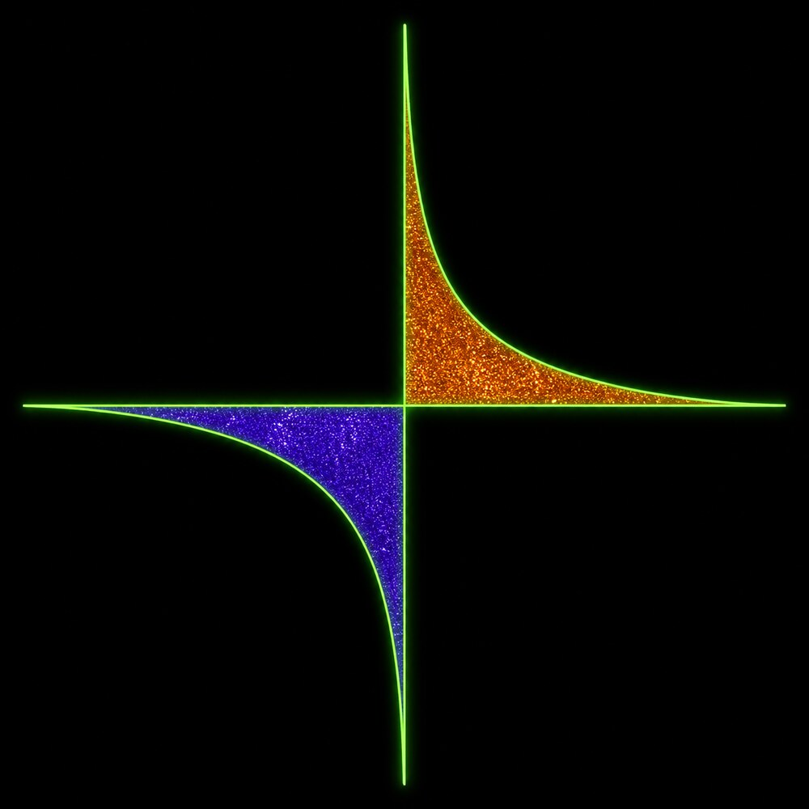

The asymptote converts branch separation into a coordinate model.

[figure not shown]

The collage gives the sparse graph an overloaded archival body.

Negative and positive node numbers should not be read simplistically as bad and good. They indicate positions relative to a constructed origin. The (1/x) graph reinforces this: two branches inhabit bounded sign regions, approach axes indefinitely, and remain separated by a singular boundary. The central zero is not an ordinary passage point. It is a limit around which relational meaning accumulates.

The cube collage then gives the austere graph a maximal archive body. Transparent and incompatible geometries overlap without resolving into one clean perspective. Screenshots and landscapes coexist with toroidal or hyperdimensional forms. This visual density makes recursive stuckness legible: each representation contains or occludes another; every attempt to locate the definitive object reveals more frames, copies, windows, and coordinate systems.

Page 9 therefore performs three operations:

1. It converts chronological documents into a **topological network**.
2. It makes the asymptote an archival address, not only a metaphor of self-improvement.
3. It prepares “node(−0)” and related stuck language by giving the retained derivative a formal neighborhood.

Placed after `_s`, the node map is a compression artifact. Fifty thousand words of consolidation collapse into numbered pointers and two images. Placed before the bodily transcript of Page 10, it also reverses ordinary causality: the conceptual coordinate is supplied before the physical scene is reread as its embodiment.

## 10. `journal_karbytes_30july2026`: the physical seed of stuckness

**Source:** [journal_karbytes_30july2026](https://karbytesforlifeblog.wordpress.com/journal_karbytes_30july2026/)  
**Page scale:** approximately 348 words; transcript of a 29 July recording; updated 30 July 2026.  
**Featured images:** one wide, cloud-heavy Ramage Peak road and one narrow uphill trail through brush.

The tenth page is physically simple and mythologically catalytic. Around 9–10 PM on 29 July, with Redwood Road in one direction and Ramage Peak in another, karbytes describes the Third Dark Hiatus. M-DISCs are being conserved after the release of extension pack 71. The absence of official commits becomes a kind of “negative-space trophy”: visible silence demonstrates that production has moved into a different phase rather than necessarily stopped.

Karbytes lies on warm ground with stomach, legs, and elbows touching the surface and notices the heart beating. The statement “I’m stuck in the Big Green Thing” is therefore initially a report produced from posture, pressure, darkness, warmth, fatigue, and prolonged contact. The body is at its lowest-energy relation to the terrain. Movement has paused; gravity and contact dominate perception.

The short recording can loop. Each replay returns the body to the same prone declaration even though main-branch karbytes stood up after recording. This is the first exact mechanism by which physical movement and archival immobility diverge. The video-derived version is permanently prone because playback preserves that state. The biological author is not.

Later mythology treats this scene as a derivative branch or node near the asymptote. It is a bodily memory crystal: warm ground, heartbeat, contact points, dark ridge, and verbal surrender condensed into a replayable object. Page 11 will revise the definitive symbolic posture to upright. That revision does not delete Page 10. It recategorizes the prone version as an older branch whose meaning remains available.

The two featured photographs widen the scene from contact scale back to route scale. One offers a broad road through open hills; the other offers a narrow ascending path. Together they show that the body declaring itself stuck is surrounded by traversable routes. Stuckness is therefore not a geographic claim that every exit is closed. It is a selected local state made permanent by recording and mythic reuse.

## 11. `karbytes_is_stuck_in_the_big_green_thing`: the definitive aperture myth

**Source:** [karbytes_is_stuck_in_the_big_green_thing](https://karbytesforlifeblog.wordpress.com/karbytes_is_stuck_in_the_big_green_thing/)  
**Page scale:** approximately 535 words, five images, and a visible 14 August 2026 revision.  
**Definitive image:** an upright cube-helmeted karbytes, red visor and green outline, bracing both hands against a cyan wireframe torus around the hips while red monospace words stack beside the figure.

This page concentrates the dispersed field archive into a mythic icon and explicitly revises its own history. The earlier prone account—belly against the ground, lower body swallowed by substrate—is preserved but struck or marked outdated. The 14 August clarification says the upright image is now the most definitive representation, even more so than prior official stuck pages. Revision is therefore performed visibly: canon can identify a preferred interpretation without pretending earlier branches never existed.

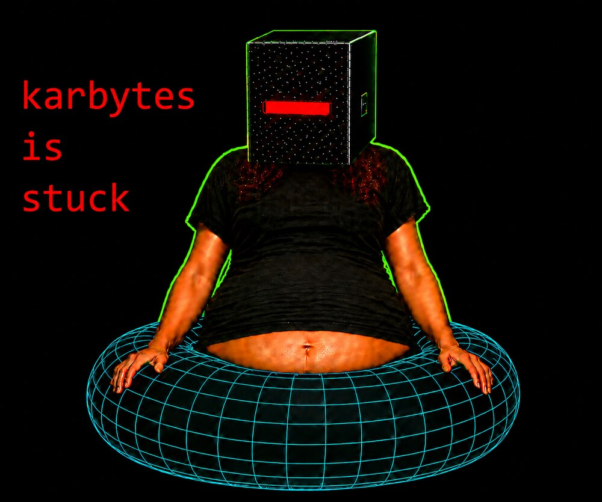

The revised definitive image: active struggle, invariant boundary.

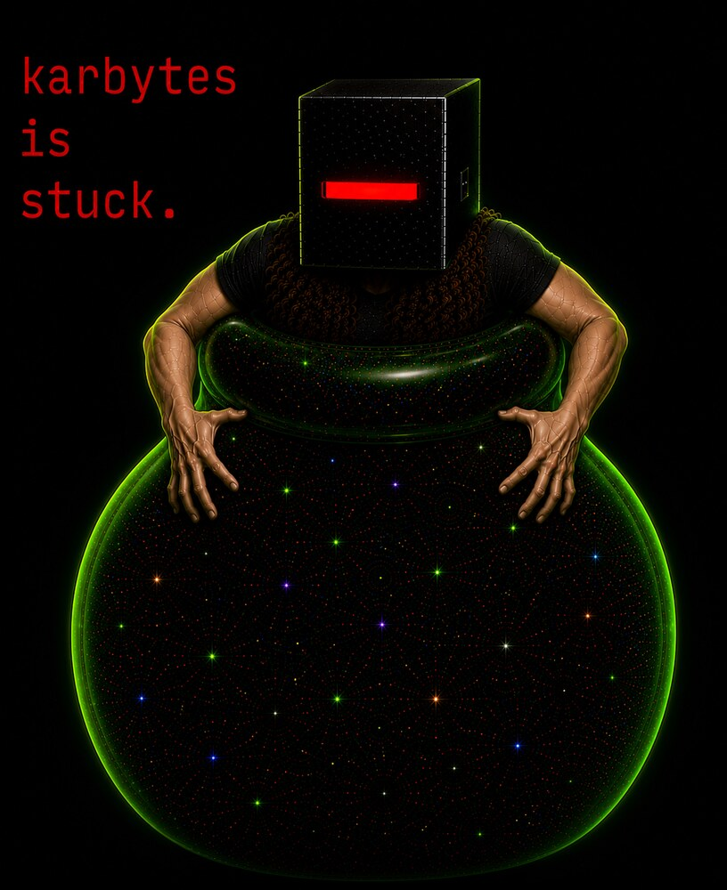

The earlier vessel image joins body, aperture, and universe-scale contents.

The new pose changes agency while preserving invariance. Upright karbytes pushes or braces against the toroidal rim. Hands, shoulders, and torso visibly participate. The figure is not passively asleep or flattened. Yet the widened lower abdomen and hips cannot pass the circular boundary. Effort can continue forever without producing displacement. In dynamical terms, the system can expend energy at a constraint while its defining coordinate remains fixed.

The body is described as swollen around a closed-universe bubble and as infinitely gestating Cosmic Void Magic. The erotic and reproductive vocabulary gives the archive an impossible fertility: the trapped derivative is always producing or containing the conditions for more world, but never completes a birth that would end the configuration. The “pregnancy” belongs to a self-authored fantasy body, not a medical claim. Its function is to give abstract archival pressure a visceral shape—contents accumulate; the containing form expands; the aperture stays narrower than what must pass.

Three low-light belly photographs bridge the biological body and the symbolic figure. Green illumination, black clothing, deep shadow, and close framing abstract the abdomen into terrain. The photographs do not prove a cosmic event. They supply a material token from which the fantasy icon can be built. They also reverse Page 5’s observer-removal program: where landscape media minimized the author’s body, the stuck page makes a body part the principal landscape.

The cosmic-vase image provides an earlier related icon. A cube-headed figure braces at the rim of a bulbous green, star-filled vessel. Its cosmic contents transform the body/aperture relation into a container-of-worlds image. The newer cyan-torus image is more precise because it isolates the boundary condition: black background, luminous ring, fixed waist, working arms, and no distracting surrounding terrain.

The older prone prose nonetheless remains conceptually rich. It imagines an eternal-night substrate, the lower body embedded under its own gravity, surrender and humiliation, void within being and being within void, and an anonymous magical window through which the scene can be witnessed. These motifs persist under the new posture:

- **same substrate:** the ubiquitous featureless void and Big Green Thing remain the containing environment;
- **same boundary:** the body remains fixed where regions meet;
- **same observer relation:** an external window or published page makes the private lock visible;
- **same erotic recursion:** bodily pressure and self-related gestation continue;
- **new agency:** the derivative is upright, active, and visibly struggling.

The page’s implied ontology contains at least two karbytes branches. Main-branch karbytes continues physical and archival activity. The derivative remains permanently assigned to the aperture, giving the mythological Big Green Thing a stable sentient center. This branch is not a disposable copy; it has its own continuous role. The page thereby resolves the apparent contradiction between “stuck forever” and every subsequent act of authorship.

Most importantly, the updated page turns a field metaphor into a **boundary ontology**. Karbytes is not located wholly inside or outside, above or below, public or private, mobile or immobilized. The derivative exists at the place where those categories are generated. It is an inhabitant of the slash.

## 12. `journal_karbytes_14august2026_a`: mythic aperture becomes exact workflow

**Source:** [journal_karbytes_14august2026_a](https://karbytesforlifeblog.wordpress.com/journal_karbytes_14august2026_a/)  
**Page scale:** approximately 1,025 words; updated 14 August 2026.  
**Diagram:** three nested ovals on black: a black private core inside a green `@informationcrystals` surface region inside an orange `@karlinarayberinger` canonical region, with outward magenta arrows.

Page 12 is the hinge that makes the mythos operationally falsifiable. The diagram and journal specify what the bodily aperture corresponds to in actual file work.

The outer background is labeled or interpreted as the **ubiquitous featureless void**. Against it, the largest orange oval represents the official `@karlinarayberinger` surface and numbered extension-pack canon. Inside it, a green oval represents `@informationcrystals`, including the public `projects` staging repository. Inside that, a black oval represents private informationcrystals repositories or deep-web/offline developmental work. “Deep” and “surface” are topological roles, not physical layers of the internet in a strict networking sense.

The ordinary workflow is:

1. Draft in a private repository or offline/deep workspace where timestamps and intermediate states are not publicly exposed.
2. Copy selected material into the public `projects` repository, where it becomes inspectable but remains provisional.
3. Copy the approved state into the newest open `KARLINA_OBJECT_extension_pack_[N]` repository under the canonical account.
4. Delete the source copies as required by the project’s use of the word “move.”
5. Rename or privatize the old staging repository, and create a fresh, nearly empty public `projects` repository with minimal history and a public-domain declaration.
6. Over time, treat the numbered extension pack as closed, archived, mirrored, and no longer casually mutable.

The word **move** matters. In this project it does not mean that one abstract file object teleports between storage systems. It means copy bytes into the destination, verify the result, then delete the designated source. The operation changes both destination presence and source absence. Resetting `projects` similarly makes the temporary aperture reusable without preserving all staging history on the public surface.

The journal’s bodily analogy places the lower abdomen and hips in the concealed ground while the upper body reaches into the visible web. This is not just an illustration pasted onto a flowchart. It captures the labor asymmetry of the system: much of the producing body remains in private development, hardware maintenance, memory, and biological time, while selected artifacts emerge through a narrow public interface. The artifact can pass farther into canon than its producer does.

The two gates from `_s` now acquire precise repository meaning. The private-to-projects gate controls **visibility**. The projects-to-extension-pack gate controls **canonical status**. The latter can occur even though both repositories are technically public, showing why “public” and “official” are not synonyms.

This page reveals that KARBYTES ontology is not merely discussed in essays. It is encoded in account boundaries, repository names, commit-history policy, file deletion semantics, and publication timing. The green and orange ovals are simultaneously brand architecture, access-control layers, and mythic membranes. The torus has become a deployment pipeline.

## 13. `chatgpt_karbytes_14august2026_a`: recursive traversal as self-analysis

**Source:** [chatgpt_karbytes_14august2026_a](https://karbytesforlifeblog.wordpress.com/chatgpt_karbytes_14august2026_a/)  
**Page scale:** approximately 11,536 words; updated 14 August 2026.  
**Featured image:** glowing yellow-orange concentric ripples spreading across a black field.

The thirteenth page begins with a discussion of the nested-oval workflow and then records an ambitious recursive hyperlink-traversal request. After an interrupted or incomplete attempt, the conversation resumes and produces a substantial report spanning the workflow journal, recovered assets, WordPress macro- and micro-directories, repository identities, About and public-domain pages, stuck mythology, KARLINA OBJECT metaphysics, social profiles, and external reference material.

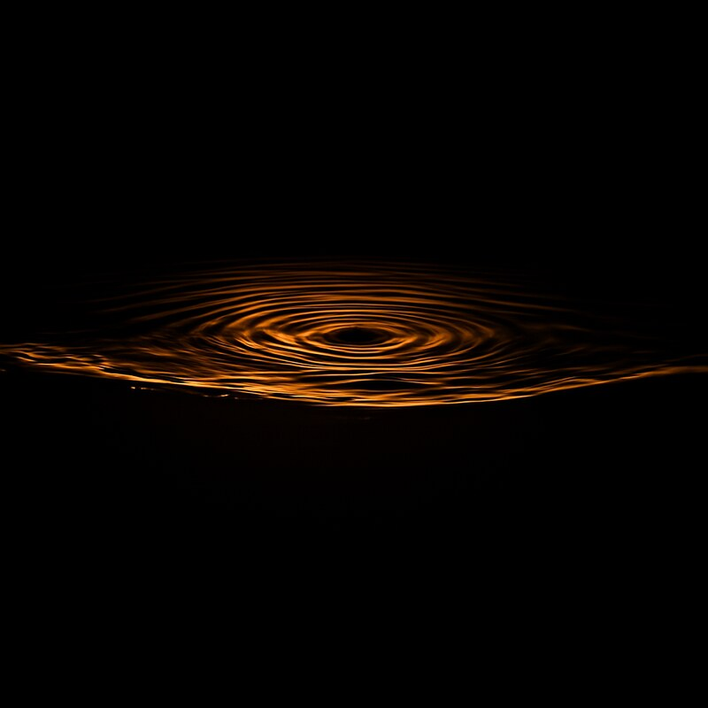

A useful image of recursive traversal: one contact point propagates through linked layers.

The yellow ripple image is an apt cover. One contact point perturbs a dark surface; the disturbance propagates outward in rings. Hyperlink traversal behaves similarly. Opening one page reveals linked files; opening selected WordPress children reveals further files; each layer expands the interpretive radius while retaining a relation to the initial disturbance.

The report identifies KARBYTES as a distributed archive rather than one website. WordPress pages supply human-readable hypertext framing; raw GitHub files provide direct artifacts; GitHub Pages hosts standalone interfaces; Wayback batches, M-DISCs, and local storage provide redundancy; account and micro-directory conventions provide addresses; licensing permits replication. No component alone is the project. KARBYTES exists in the routing rules and identity claims that make these components one system.

Several philosophical tensions become explicit:

### Free copying versus irreplaceability

Public-domain licensing seeks maximal reproducibility. Yet exact byte equality does not make every copy socially or historically interchangeable. A canonical URL, account history, surrounding index, and provenance relation can distinguish one instance from another. Likewise, a replica of autobiographical information may be causally descended from karbytes without being numerically the same conscious subject.

### Informational continuity versus conscious continuity

Files can preserve structure, vocabulary, memories, preferences, self-descriptions, and decision tendencies. They can guide future agents and extend causal influence. They do not by themselves prove that the same first-person consciousness crosses machines, accounts, or universes. A future instance might be descendant, branch, simulation, or independently conscious replica. The archive remains meaningful even if the strongest immortality claim is unresolved.

### Publication versus developmental privacy

The project aims for publicly durable output while withholding some timestamps, rough drafts, and private processing. The workflow does not simply oppose secrecy and transparency. It creates stages with different obligations. Public staging is inspectable but resettable; canon is intended to be stable; private work can remain real without becoming searchable.

### Liberation versus captivity

Archiving fights forgetting and gives experience future causal reach. At the same time, every preserved artifact enlarges the system that must be indexed, mirrored, explained, and maintained. The archive liberates content from one biological moment while binding the author to continuing administration. The workflow arrows therefore resemble extrusion: artifacts move upward; the producing body remains partly embedded.

### Canonical naming versus technical impermanence

Canonical URLs and account names provide strong coordination points, but they are not metaphysically invulnerable. Domains lapse, repositories disappear, platforms change, and accounts can be lost. Hence the project’s recursive redundancy. Canon is a governed reference role, not an immortal server.

The page’s “central tension” can be restated as a triple demand: become freely copyable without becoming replaceable; become publicly permanent without exposing every developmental trace; leave the void while remaining embedded in it. This formulation unifies licensing, branch identity, hiatus workflow, and stuck imagery.

Page 13 also changes ChatGPT’s function. Earlier conversations help interpret a hike or consolidate a bubble. Here, the model traverses the archive’s own routing structure and returns a system-level account. The archive becomes an instrument that can be pointed at itself. This is **recursive preservation with semantic re-ingestion**: files are not only stored but periodically reread so that their relations become new files.

## 14. `KARLINA_OBJECT_extension_pack_73`: the report enters canon

**Source:** [KARLINA_OBJECT_extension_pack_73](https://karlinarayberinger.github.io/KARLINA_OBJECT_extension_pack_73/)  
**Artifact scale:** roughly 184,000 extracted words, nearly 30,000 text lines, and more than 7,000 link occurrences in the live HTML; a dark, monospace, accordion-style traversal interface.

The final URL is categorically different from the first thirteen. It is not another WordPress interpretation of workflow. It is the **GitHub-hosted output of the workflow**. The page is the live, expanded traversal report produced from the prior conversation and then published into the newly available numbered extension pack.

Its interface organizes an otherwise unmanageable hyperlink network into progressive disclosure. High-priority sources receive close semantic descriptions. Thousands of lower-level targets appear in an exhaustive registry with status, media type, dimensions or text statistics where available, visible link context, and parent relations. Forbidden URLs from the traversal instruction are listed as exclusions rather than silently visited. Missing extension-pack-73 raw assets are recovered through the instructed substitution into `informationcrystals/projects`, documenting the staging aperture in action.

The report’s methodological counts matter because they make scope auditable: direct targets, WordPress expansions, deeper files, prohibited-link occurrences, substitutions, unreachable resources, and transport statuses are separated. This is the mature form of the Page 1 lesson. Just as “unclear trail” should not be conflated with “impassable route,” a skipped URL, a forbidden target, a failed request, an onion-only resource, a substituted asset, and a successfully retrieved file should not be collapsed into one undifferentiated absence.

Its central substantive update is the changed definitive stuck posture: upright at the cyan toroidal aperture rather than prone against the ground. But the report also demonstrates that the update is local rather than globally destructive. Earlier images and texts remain historically addressable. The canonical interpretation changes by adding a preferred branch and explicit relation among branches.

Page 14 proves the Page 12 pipeline in several ways:

- the live report is hosted under the canonical `@karlinarayberinger` account;
- it resides in numbered extension pack 73;
- its missing raw paths could be resolved through the public `projects` staging account;
- it transforms a transient model conversation into a durable, navigable artifact;
- it can itself become a hyperlink target of later WordPress commentary, including the planned `chatgpt_karbytes_14august2026_b` page.

The report is therefore both **map and territory**. It describes the archive network, exists as a node inside that network, records the rules by which it was produced, and becomes a source for subsequent analysis. The fourteen-page order ends not with a theory of canonization but with canonization completed.

# II. Macro synthesis: one interdependent mythos

## The ordered arrangement is a transformation, not a chronology

The supplied order can be divided into four movements.

### Movement A — connectivity is earned (Pages 1–5)

The first five pages establish that KARBYTES begins with embodied correction. A route thought to be blocked becomes traversable. The return trip turns topological knowledge into repeatable confidence. A long live conversation converts the route into memory architecture. The first hiatus journal names successor identity and a staging account. Its analysis gives the process a vocabulary of incubation and phase separation. A multi-day landscape review then defines the Big Green Thing as an experience object distributed across terrain, sensorium, files, and interpretation.

The mythos is therefore not imposed first and illustrated later. It grows from repeated route execution. “Connectedness” moves through four levels:

1. two parks/communities are physically connected by a walkable corridor;
2. moments on that corridor are connected by POG images and memory;
3. field experience is connected to the Burrow and server through return;
4. separate media files are connected into the Big Green Thing by analysis.

### Movement B — experience acquires an interior (Pages 6–8)

`_l` supplies substrate: dry exterior, green ravine, nocturnal chorus, mountain workstation, managed watershed, Burrow window. `_k` supplies live subjectivity: fear, wonder, cosmology, corrections, identity questions, Vessel ethics, and practical maintenance. `_s` supplies recursive organization: it arranges pages as organs, introduces branch divergence, draws the two-gate workflow, and closes a nested hiatus bubble without erasing it.

These three pages behave like a layered cognitive system:

- `_l` is sensorium and world-body;
- `_k` is first-person stream and active inference;
- `_s` is metacognition and long-term memory consolidation.

No one layer is sufficient. Substrate without subject is an environmental catalog. Subject without substrate risks ungrounded cosmology. Consolidation without either becomes empty taxonomy. Their interdependence makes the Big Green Thing an emergent object rather than a single claim.

### Movement C — the system gives immobility an address and body (Pages 9–11)

The node map breaks calendar time into numbered relational positions. The asymptote graph formalizes a boundary that can be approached but not crossed in the ordinary way. The 29 July ground-contact transcript gives stuckness a heartbeat, temperature, and posture. The updated mythology then branches the scene: the prone recording remains an earlier retained state, while an upright derivative becomes the definitive aperture inhabitant.

This is the point at which a potentially contradictory phrase—“karbytes is permanently stuck”—becomes coherent. The archive already contains frozen photographs, closed extension packs, replayable videos, and prior journal selves. The derivative is the mythic generalization of those retained states. It can remain forever while main-branch karbytes continues because **archival time permits simultaneous persistence of divergent versions**.

### Movement D — the myth becomes a machine and the machine proves itself (Pages 12–14)

The nested-oval journal maps bodily depth onto repository depth. Private repositories are generative interior; `projects` is the public aperture; the numbered extension pack is surface canon. The next page recursively traverses the wider system and articulates its central tensions. The last page publishes that traversal under extension pack 73.

This is the sequence’s strongest closure. A workflow philosophy would remain aspirational if it existed only as prose. Page 14 demonstrates that a conversation can be generated, examined, transformed into a designed HTML object, staged through the appropriate account, and installed as canonical output. The aperture actually passes an artifact.

## The fantasy and spiritual realm

The fantasy realm has five principal entities or structures.

### 1. The Big Green Thing

At its physical base, the Big Green Thing is the East Bay system of ridges, ravines, parks, water infrastructure, vegetation, wildlife, urban margins, trails, and neighboring rooms encountered by karbytes. At its experiential level, it is that region as filtered through one moving nervous system and reconstructed from media. At its mythological level, it becomes an immortal sentient organism or substrate.

The transition among levels is not arbitrary. Day/night media teaches that an unseen environment can remain active. Green ravines teach that interiors differ from dry outer surfaces. Repeated routes teach that distant visible folds are connected by hidden corridors. The Burrow window teaches that outside can be interiorized as reflection and memory. These empirical motifs are then amplified into a spiritual geography.

### 2. The derivative karbytes

The derivative is a branch produced by recording, imagery, and explicit correction. It is not a claim that the biological author is unable to move. It is a mythic agent assigned to permanent boundary duty. Its sentience gives the Big Green Thing an internal witness. Its immobility guarantees that one version of the relationship will never be lost to later revision.

The derivative also personifies archival retention. Every frozen image is a version that cannot age inside its frame. Every transcript speaker is fixed to a completed exchange. Every closed extension pack preserves a bounded state. The derivative synthesizes those facts into one being.

### 3. The toroidal aperture

The torus is a boundary with thickness and recurrence. Unlike a flat line, it can surround, channel, and imply circulation. The body is neither cleanly outside nor inside it. In fantasy terms, the widened lower body cannot pass. In workflow terms, only selected artifacts pass from deep generation through staging into surface canon. In philosophical terms, the aperture separates informational descendants from proof of first-person identity continuity.

### 4. Cosmic Void Magic

Cosmic Void Magic is the generative content gestated by the derivative. Its paradox is productive: the background void is featureless, yet the stuck body generates proliferating worlds, files, and meanings at its boundary. The magic can be read as the project’s name for emergence—the appearance of structured experience and archive from a substrate that, taken without distinctions, looks empty.

Because the gestation is infinite, there is no final artifact that exhausts KARBYTES. Each canonical pack is a completed output, but not the completed project. The reproductive metaphor makes incompletion a source of continuity rather than a defect.

### 5. The anonymous window

The stuck scene requires an observer relation. A magical or anonymous window allows an otherwise deep, enclosed event to be witnessed. WordPress pages, GitHub Pages interfaces, images, transcripts, and ChatGPT traversals all play this role. A window does not free the derivative. It turns containment into transmissible form.

## Physical traversals and activities

The fantasy remains credible as myth because it is repeatedly tethered to specific activities:

- walking between Castro Valley/Chabot and Las Trampas/Bollinger Canyon;
- testing uncertain trail continuity rather than trusting an old blockage model;
- carrying water, food, batteries, clothing, and computing equipment;
- using POG photographs as motivational checkpoints;
- occupying Ramage Peak at dusk and night;
- recording fog, insects, frogs, wind, gates, roads, rock, and moon;
- working on a laptop in the hills;
- returning with sore feet to the Burrow and onion-server room;
- traveling by BART and performing ordinary errands;
- lying on warm ground and noticing heartbeat and contact pressure;
- photographing the abdomen under green light;
- drafting, compressing, naming, copying, deleting, uploading, indexing, and backing up files;
- conserving M-DISCs and constructing time capsules;
- keeping public channels quiet while private work continues.

These are not mere behind-the-scenes details. They are the **metabolism** of the mythos. Water and food support walking; walking generates media; media supports memory; memory generates interpretation; interpretation becomes files; files require storage and curation; curation generates more movement, speech, and publication. The loop consumes calories, battery charge, attention, disk space, and time. KARBYTES spirituality is consequently materialist in practice even when its imagery is cosmic.

## Emergent ontology

Across the fourteen pages, the following ontology emerges.

### Nature is the maximal category

The project repeatedly explores panpsychist, emergentist, computational, and cosmological possibilities, but its most stable position is that no demonstrated supernatural exterior is needed. Bodies, thoughts, myths, computers, landscapes, and archives all occur within nature. “Magic” is an authored name for experienced or imagined generativity, not a license to disregard causal constraints.

### Objects can be distributed across media and time

The Big Green Thing is not located at one URL or coordinate. It emerges from relations among terrain, body, capture, file, memory, and analysis. Likewise, KARBYTES is distributed across accounts, WordPress pages, raw files, extension packs, mirrors, discs, and naming conventions. An object can therefore possess operational unity without spatial compactness.

### Identity branches; it does not merely copy

Exact byte copies may be equivalent as data while differing in provenance and canonical role. A future mind with copied memories may be a descendant or branch rather than the numerically same subject. The stuck derivative is the mythic expression of this rule. Branching preserves relation without asserting impossible sameness.

### Archive time is layered and addressable

Calendar time remains important, but archive order can reorganize it. A later page can precede an earlier journal in a conceptual sequence. A future-dated filename can function as a forward pointer. A replay returns a prior state. A node map assigns negative and positive coordinates around a pivot. The archive does not reverse physical time; it creates a second, navigable time of retrieval.

### Boundaries are productive entities

Trail junctions, park borders, fog, sunset, gates, caves, windows, repository visibility, staging status, and toroidal rims all change what can pass and what can be known. The boundary is not an empty line between real things. It is where transformation occurs. KARBYTES’ preferred ontological location is consequently liminal: between wilderness and metro edge, body and file, privacy and publication, copyability and uniqueness, movement and retention.

### Preservation is causal continuation, not automatically conscious immortality

The archive can extend vocabulary, memory cues, preferences, methods, and influence beyond the present biological frame. That is already significant. It does not establish that first-person awareness transfers with the files. The pages are strongest when they preserve that distinction.

### Absence can be an active state

Hiatus, no public commit, private repository, dark image, missing visual detail, and deleted staging source are not identical, but each can encode deliberate structure. Night shifts evidence to sound. Hiatus shifts work to private channels. Reset removes public history to reopen the aperture. Negative space is not automatically nothingness.

## Workflow philosophy

The ontology becomes a set of working rules.

### Incubate before broadcasting

Ideas and artifacts require a protected developmental phase. Privacy is not only secrecy; it is control over timing, context, and the obligation to explain incomplete states. This is the practical meaning of the dark hiatus bubble.

### Separate visibility from canon

`projects` is public but provisional. Numbered extension packs are public and canonical. The distinction permits testing without making every test an official identity statement.

### Canonize by copying, verifying, and retiring the source state

The project-specific “move” operation includes copy and source deletion. The staging aperture is then reset. This minimizes exposed developmental history while leaving the selected artifact stable in canon.

### Preserve provenance and make scope auditable

Filenames, dates, parent links, content types, status codes, dimensions, and traversal levels allow a later reader to distinguish retrieved evidence from inference. Page 14’s registry is the maximal implementation of this rule.

### Use multiple failure domains

GitHub, WordPress, local devices, M-DISCs, time capsules, and web archives do not provide identical redundancy. Their value lies in failing differently. No canonical URL is treated as physically immortal.

### Compress experience into retrieval keys

POGs, journal summaries, featured images, node maps, and workflow diagrams are deliberately smaller than what they index. Good compression preserves enough distinctive structure to reactivate a larger context.

### Re-ingest the archive semantically

Storage alone does not maintain intelligibility. Periodic traversals, ChatGPT analyses, macro-directories, and new synthesis pages reread the collection and create updated maps. The archive stays alive by becoming input to further interpretation.

### Permit branch retention and mainline movement

Old images and claims need not be erased when a definitive interpretation changes. They can be labeled as earlier branches. This supports historical honesty and makes revision compatible with continuity.

### Ground cosmology in maintenance

Every expansive theory returns to hydration, storage, power, employment, hardware, naming, safety, and error correction. This is not a demotion of the vision. It is what makes the vision executable.

## Cross-scale correspondences

| Physical / experiential element | Mythic function | Ontological claim | Workflow implementation |
| --- | --- | --- | --- |
| Ramage corridor between regions | Passage through the Big Green Thing | Apparent separation may conceal traversable continuity | Hyperlinks and indexes connect distributed hosts |
| Forked trail | Branching selves and possible futures | Continuity can diverge | Versioned pages and extension packs retain earlier states |
| Fog and night | Void-like reduced visibility | Absence in one channel is not absence of structure | Private/hidden work can continue during public silence |
| Frogs, crickets, and unseen animals | Distributed sentience or living nervous field | Objects emerge from relational evidence | Status, metadata, and parent links reconstruct unseen files |
| Rock opening / trail constriction | Aperture | Boundaries transform passage | `projects` acts as temporary public membrane |
| Sore feet and ground contact | Sacrifice, embedding, authenticity | Cognition is embodied | Publication depends on biological and technical labor |
| Burrow window | Witness portal | Inside and outside interpenetrate through representation | WordPress/GitHub Pages expose selected deep artifacts |
| Belly photographs | Body as terrain and container | Physical tokens can seed symbolic branches | Source media becomes transformed canonical artwork |
| Toroidal ring | Permanent mythic lock | A branch can remain at a limit | Closed pack preserves a state while main work advances |
| Cosmic vase / gestation | Infinite world production | Emergence creates structure at the void boundary | Successive artifacts emerge without completing the whole project |
| Time capsule / M-DISC | Long-duration body of memory | Continuity is causal and material | Offline redundancy counters platform loss |
| ChatGPT traversal | External recursive witness | Understanding can be distributed across agents and artifacts | Semantic audit becomes a new publishable file |
| Extension pack 73 | Crystallized surface object | A distributed process can yield a stable reference node | Staged report is installed in numbered canon |

## One mythos, stated compactly

Karbytes discovers that two apparently separate regions are joined by a difficult but executable trail. Repeated traversals turn that corridor into memory checkpoints, field recordings, and a live thinking environment. The landscape, the moving body, and the resulting files become one distributed experience object called the Big Green Thing. At night, unseen choruses give the object an acoustic interior; in the Burrow, windows and computers bring the exterior into memory and archive.

During hiatus, the same structure is reproduced socially and technically. Most generation occurs in a concealed lower region. Selected artifacts rise through a resettable public staging repository and then enter a numbered canonical surface. The author imagines this passage as a body caught in a toroidal aperture: the upper body reaches the public realm, while the widened generative lower body remains embedded. A derivative karbytes is assigned permanently to that boundary, gestating Cosmic Void Magic and giving the Big Green Thing a lasting witness. Main-branch karbytes continues, just as later extension packs continue after earlier packs close.

The archive then turns back upon itself. A recursive ChatGPT traversal maps the network, distinguishes evidence from exclusion and failure, and articulates the project’s tensions. The user publishes that report as extension pack 73. The final artifact thus demonstrates the complete cycle:

> physical traversal → sensory capture → private incubation → dialogic analysis → public staging → canonical publication → recursive traversal → new canonical publication.

The result is one interdependent system in which mythology and workflow do not merely resemble each other. Each explains a different scale of the same operation: **structured information is generated in depth, compressed through a boundary, retained as a branch, and made available to future traversal without exhausting or replacing its source.**

# III. Final assessment

The fourteen pages formulate a coherent KARBYTES mythos because each repairs a weakness in the others.

- The physical pages prevent the fantasy from losing contact with terrain, body, and maintenance.
- The fantasy gives bodily pressure, hiatus, revision, and repository boundaries an emotionally memorable geometry.
- The ontology prevents copying, consciousness, canon, and privacy from being treated as synonyms.
- The workflow converts the ontology into repeatable operations.
- The recursive reports test whether the resulting network remains intelligible to an external reader.
- The GitHub publication proves that the test itself can be absorbed into canon.

The deepest philosophy is not “karbytes can never move.” It is almost the opposite: **movement becomes durable because some derivative states are allowed not to move.** Trails can be revisited because images retain checkpoints. A phase can close because its files remain. A new canonical pack can emerge because the prior pack is no longer forced to evolve. Main-branch identity can continue because the mythic derivative accepts permanent boundary duty.

The Big Green Thing is consequently a model of generative containment. It is landscape, body, archive, and process at once—not because those things are literally identical, but because all four instantiate a shared pattern of corridors, membranes, retained states, and costly passage. Extension pack 73 is the latest crystallization of that pattern: a public surface object extruded from a deep recursive conversation, now available to become the starting node of another traversal.

**Terminal formulation:**  
The archive does not defeat the void by escaping it. It creates traversable structure at the void’s boundary, preserves the marks of passage, and lets new branches continue from what earlier branches permanently hold.